# Lab 8

Di Deng

2020/7/26

## Packages

```r
library(readxl)
library(tidyverse)
```

## Data

Dataset from American National Election Study 2016

```r
anes = read_excel("ANESANOVA.xlsx") ## This should be your path to the data
str(anes)
```

```
## Classes 'tbl_df', 'tbl' and 'data.frame':    4270 obs. of  8 variables:
##  $ CaseID            : num  4 6 9 11 13 23 24 25 26 34 ...
##  $ DemTherm          : num  30 15 15 0 40 50 40 15 50 0 ...
##  $ GOPTherm          : num  70 30 60 60 70 15 60 40 50 60 ...
##  $ HillaryTherm      : num  0 0 15 0 40 60 30 0 0 0 ...
##  $ TrumpTherm        : num  60 50 60 50 30 0 60 60 70 100 ...
##  $ LikelyVoter       : chr  NA "1. Extremely likely" "5. Not likely at all" "3. Moderately likely" ...
##  $ LikelyVoterNumeric: num  NA 1 5 3 1 1 1 1 5 1 ...
##  $ Party             : chr  "1. Closer to Republican" "1. Closer to Republican" "1. Closer to Republican" "1. Closer to Republican" ...
```

## ANOVA

Analysis of variance (ANOVA) answers questions alike the following:

$H_0:$ Numeric variable X is the same across all subgroups

$H_A:$ At least one of the subgroups has a different X than the others

```r
aov1 = aov(HillaryTherm~Party, anes)
summary(aov1)
```

```
##               Df Sum Sq Mean Sq F value Pr(>F)
## Party          2 376127  188064   294.3 <2e-16 ***
## Residuals   1557 994788     639
## ---
## Signif. codes:  0 '***' 0.001 '**' 0.01 '*' 0.05 '.' 0.1 ' ' 1
## 2710 observations deleted due to missingness
```

```r
lm1 = lm(HillaryTherm~Party, anes)
summary(lm1)
```

```
##
## Call:
## lm(formula = HillaryTherm ~ Party, data = anes)
##
## Residuals:
##     Min      1Q  Median      3Q     Max
## -56.713 -17.754  -2.754  15.113  82.246
##
## Coefficients:
##                              Estimate Std. Error t value Pr(>|t|)
## (Intercept)                    17.754      1.132   15.69   <2e-16 ***
## Party2. Neither                17.133      1.548   11.07   <2e-16 ***
## Party3. Closer to Democratic   38.960      1.609   24.21   <2e-16 ***
## ---
## Signif. codes:  0 '***' 0.001 '**' 0.01 '*' 0.05 '.' 0.1 ' ' 1
##
## Residual standard error: 25.28 on 1557 degrees of freedom
##   (2710 observations deleted due to missingness)
## Multiple R-squared:  0.2744, Adjusted R-squared:  0.2734
## F-statistic: 294.3 on 2 and 1557 DF,  p-value: < 2.2e-16
```

Note: ANOVA is essentially a special case of linear models.

## Exercise 1 15%

Is there signifcant difference in rating for Trump among voters with different inclination to vote? Use aov to find out.

## Simple Linear Regression

$$Y_i = \beta_0 + \beta_1 X_i + \epsilon_i, \text{ where } \epsilon_i \overset{iid}{\sim} N(0, \sigma^2) \text{ for all } i$$

Conditions:

- Linearity: The relationship between X and the mean of Y is linear and residuals have zero mean.
- Homoscedasticity: The variance of residual is the same for any value of X.
- Independence: Observations are independent of each other.
- Normality: For any fixed value of X, Y is normally distributed.

### Visualization

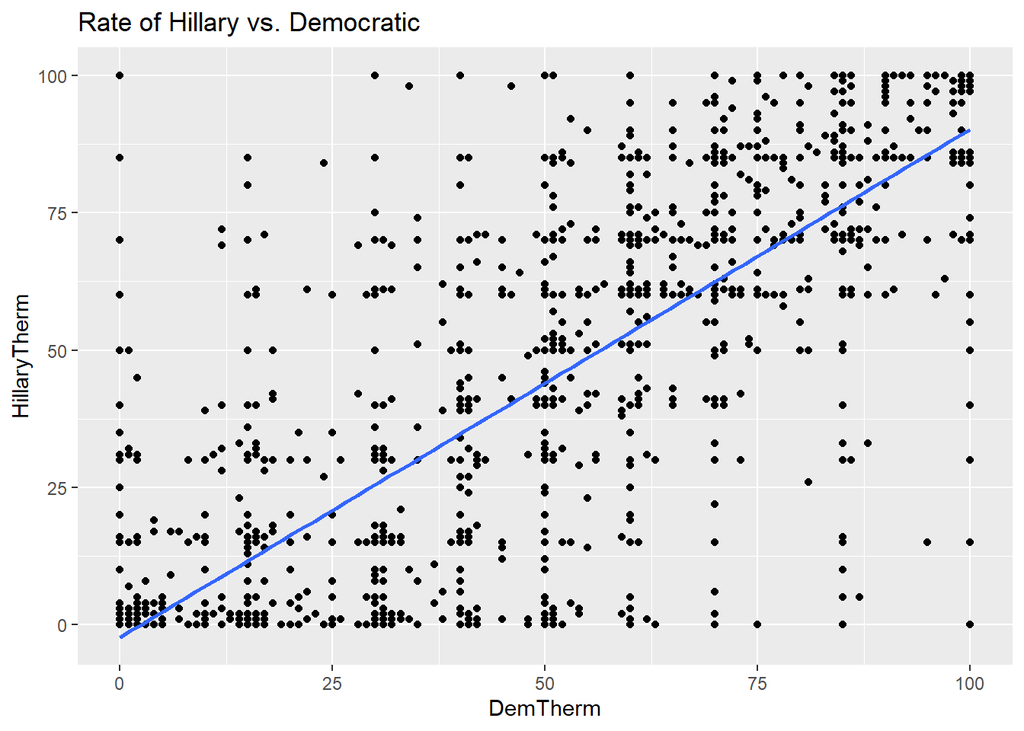

```r
lm_ex = lm(data = anes, HillaryTherm~DemTherm)
ggplot(anes, aes(x = DemTherm, y = HillaryTherm)) + geom_point() + geom_smooth(method='lm', se=FALSE) + ggtitle("Rate of Hillary vs. Democratic")
```

## Exercise 2 10%

Plot a scatterplot for any two numeric variables and add a linear line to it.

## Exercise 3 10%

Add position=position_jitter() in geom_point() and comment on the change. What does this new argument do?

## lm()

lm() function has two required arguments: data and formula. Y~X1 + X2 is the formula, with Y being the response and Xs being the predictor.

## Exercise 4 15%

Use lm() to fit a simple linear model for the two variables you chose in exercise 2. Print out and look at the summary of the model.

## Exercise 5 25%

What are the coefficients? Write out the linear model and interpret. Are they statistically significant?

## Diagnostic plot

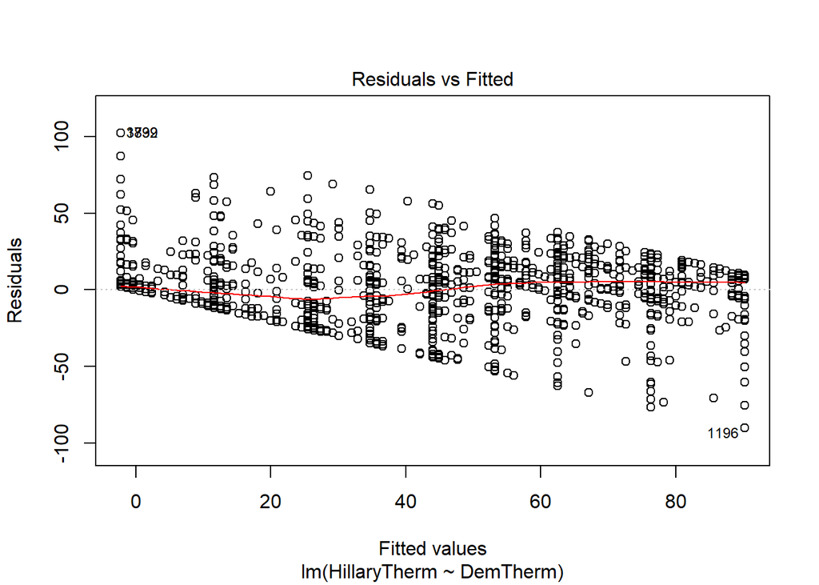

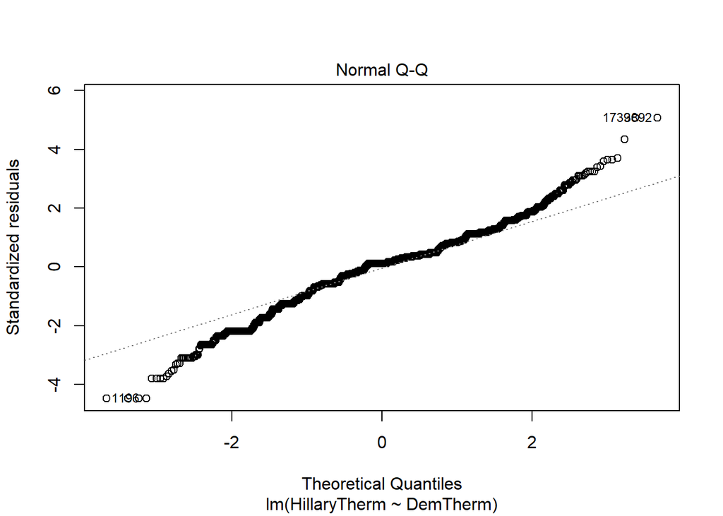

```r
plot(lm_ex, which=c(1,2))
```

These plots violates linearity and normality. So we wouldn’t trust the results of the model.

## Exercise 6 20%

Use plot() function to look at residual plot and normal q-q plot. Are those conditions of linear model met? If not, should we trust the p-values in the summary?

## Exercise 7 5%

Add another variable to your linear model and print out the summary.